# Forecast evaluation (jumeau)

# Forecast evaluation (jumeau)

**Jumeau version** of `06_evaluation.qmd`, used to test external drivers in the block models (here: the mortgage rate for rents). It uses `R/models_jumeau.R` and writes its results to `output/jumeau/` and `figures/jumeau/`, so the original results are not modified. The text below comes from the original file and has not been updated yet: the numbers in the tables are the ones to read.

This file follows `05_forecasting.qmd`. We evaluate the bottom-up forecast of headline year-on-year inflation **out-of-sample**: we repeat the whole forecasting procedure at many past dates, using only the data available at each date, and compare the forecasts with what actually happened.

The steps are:

1. **Recursive forecasts**: our model and four benchmarks, from every origin between 2012Q4 and 2026Q2, 1 to 12 quarters ahead.
2. **Spaghetti chart**: every forecast path against the outcome.
3. **Absolute standards**: is the forecast unbiased and efficient?
4. **Relative standards**: is it more accurate than the benchmarks?

All functions used here (`forecast_point()`, `wald_hac()`, `dm_test()`, …) are in `R/models.R`.

```r
library(here)
library(tidyverse)
library(sandwich)   # NeweyWest(), used by wald_hac()
source(here("R", "models_jumeau.R"))

# Parameters. When the project is run with main.R, its values are used;
# otherwise the same values are set here so the file can be rendered alone.
if (!inherits(get0("start_estimation"), "Date")) start_estimation <- as.Date("2000-01-01")
if (!inherits(get0("first_origin"), "Date"))     first_origin     <- as.Date("2012-10-01")
if (!exists("fcst_horizon"))     fcst_horizon     <- 12
if (!all(c("rent", "imp_xoil", "dom_xrent", "headline", "headline_ar1") %in% names(get0("arima_specs")))) {
  arima_specs <- list(rent      = list(order = c(3, 1, 0), driver = "mortgage_rate", driver_lags = 2),
                      imp_xoil  = list(order = c(0, 1, 2),
                                       dummy = c(from = "2009-01-01", to = "2016-10-01")),
                      dom_xrent = list(order = c(1, 1, 1), driver = "policy_rate", driver_lags = 1),
                      headline     = list(order = c(0, 1, 1)),
                      headline_ar1 = list(order = c(1, 1, 0)))
}

dir.create(here("output", "jumeau"), recursive = TRUE, showWarnings = FALSE)
dir.create(here("figures", "jumeau"), recursive = TRUE, showWarnings = FALSE)

# Quarterly data from 2000Q1, with logs x 100 and headline y-y inflation
q <- load_quarterly(start_estimation)
H <- fcst_horizon

# Forecast origins: from first_origin to the second-to-last quarter, so that
# at least one outcome is observed for every origin
origins <- which(q$date >= first_origin & q$date < max(q$date))
range(q$date[origins])
```

```
[1] "2012-10-01" "2026-04-01"
```

```r
length(origins)
```

```
[1] 55
```

We use 55 forecast origins, from 2012Q4 to 2026Q2. The number of evaluated forecasts falls with the horizon, from 55 at h = 1 to 44 at h = 12, since the outcome must be observed.

# 1. Recursive forecasts

```r
# Expanding window: at each origin t we use the data 2000Q1..t only, i.e.
# we re-run the X-13 seasonal adjustment, re-estimate all four block models,
# forecast h = 1, ..., 12 with random-walk Brent and USD/CHF, add the X-13
# seasonal component back, and aggregate to headline y-y inflation.
# Nothing after t is used, so the forecasts are what we could have produced
# in real time (apart from data revisions, which are small for the CPI).
#
# Benchmarks, computed at every origin as well:
#   arima: the same approach applied directly to headline CPI (X-13
#          adjustment, ARIMA(0,1,1) from main.R, seasonal component added
#          back), i.e. without disaggregation. Shows whether forecasting the
#          four blocks separately adds value.
#   ar1:   AR(1) on quarterly headline inflation, i.e. ARIMA(1,1,0) with
#          drift on adjusted headline CPI, seasonal component added back.
#          The standard simple benchmark for inflation forecasts.
#   rw:    y-y inflation stays at its last observed value (random walk).
#   mean:  sample mean of y-y inflation up to the origin (white-noise
#          benchmark of the course). 1 - MSFE ratio against it is the
#          predictive R-squared.
recursive <- map_dfr(origins, function(t) {
  hist <- q[1:t, ]
  fc   <- forecast_point(hist, H, arima_specs)

  # Headline benchmarks: X-13 on headline CPI, model on the adjusted series,
  # seasonal component added back, then y-y inflation (the level four
  # quarters earlier is observed for h <= 4, forecast afterwards)
  y   <- hist$y_cpi
  adj <- x13_adjust(hist$cpi_total, min(hist$date), H)
  headline_yy <- function(spec) {
    y_fc  <- arima_paths(fit_arima(adj$sa, spec), adj$sa, H) + adj$sf_fc
    y_all <- c(y, drop(y_fc))
    y_all[length(y) + 1:H] - y_all[length(y) + 1:H - 4]
  }

  n_t <- nrow(hist)
  blk_yy <- map_dfc(setNames(nm = block_names), function(b) {
    y_all <- c(hist[[paste0("y_", b)]], drop(fc$blocks[[b]]))
    y_all[n_t + 1:H] - y_all[n_t + 1:H - 4]
  }) %>% rename_with(~ paste0("fc_", .x))
  w_t <- as_tibble_row(setNames(latest_weights(hist), paste0("w_", block_names)))

  bind_cols(
    tibble(origin = q$date[t], h = 1:H, target = fc$dates,
           model = fc$headline,
           arima = headline_yy(arima_specs$headline),
           ar1   = headline_yy(arima_specs$headline_ar1),
           rw    = hist$pi_cpi[t],
           mean  = mean(hist$pi_cpi, na.rm = TRUE),
           pi_origin = hist$pi_cpi[t],
           brent_yy_origin = hist$y_brent[t] - hist$y_brent[t - 4]),
    blk_yy, w_t)
})

# Add the outcome (observed headline y-y inflation at the target date)
recursive <- recursive %>%
  left_join(q %>% select(target = date, actual = pi_cpi), by = "target")
write_csv(recursive, here("output", "jumeau", "eval_forecasts.csv"))

# Forecasts with an observed outcome, and their errors (e = actual - forecast)
evaluated <- recursive %>% filter(!is.na(actual)) %>% mutate(error = actual - model)

# Last forecast error known at the origin, for the strong-efficiency test:
# the error of the h-step forecast made h quarters earlier, whose target is
# the origin itself (so its outcome is observed at the origin). Missing for
# the first h origins.
evaluated <- evaluated %>%
  mutate(origin_prev = origin %m-% months(3 * h)) %>%
  left_join(evaluated %>% select(origin_prev = origin, h, error_lag = error),
            by = c("origin_prev", "h")) %>%
  select(-origin_prev)
count(evaluated, h) %>% as.data.frame()
```

```
    h  n
1   1 55
2   2 54
3   3 53
4   4 52
5   5 51
6   6 50
7   7 49
8   8 48
9   9 47
10 10 46
11 11 45
12 12 44
```

```r
# Case study at h = 8 (two years ahead): for a few origins with inflation far
# from its long-run level (2015-16 strong franc, 2019 pre-COVID, 2021-23 surge),
# compare the move our forecast predicted away from current inflation
# (model - pi_origin) with the move that actually happened (actual - pi_origin).
# Same sign and similar size = the predicted mean reversion took place.
evaluated %>%
  filter(h == 8,
         origin %in% as.Date(c("2015-04-01", "2016-01-01", "2019-10-01",
                               "2021-01-01", "2022-07-01", "2023-04-01"))) %>%
  transmute(origin, pi_origin, model, actual,
            predicted_move = model - pi_origin,
            actual_move    = actual - pi_origin) %>%
  mutate(across(-origin, ~ round(.x, 2))) %>%
  as.data.frame()
```

```
      origin pi_origin model actual predicted_move actual_move
1 2015-04-01     -1.12  0.48   0.37           1.60        1.49
2 2016-01-01     -0.99  0.39   0.72           1.38        1.71
3 2019-10-01     -0.08  0.53   1.42           0.60        1.50
4 2021-01-01     -0.43  0.38   3.15           0.81        3.58
5 2022-07-01      3.32  0.97   1.06          -2.35       -2.26
6 2023-04-01      2.12  1.03   0.00          -1.09       -2.12
```

# 2. Spaghetti chart

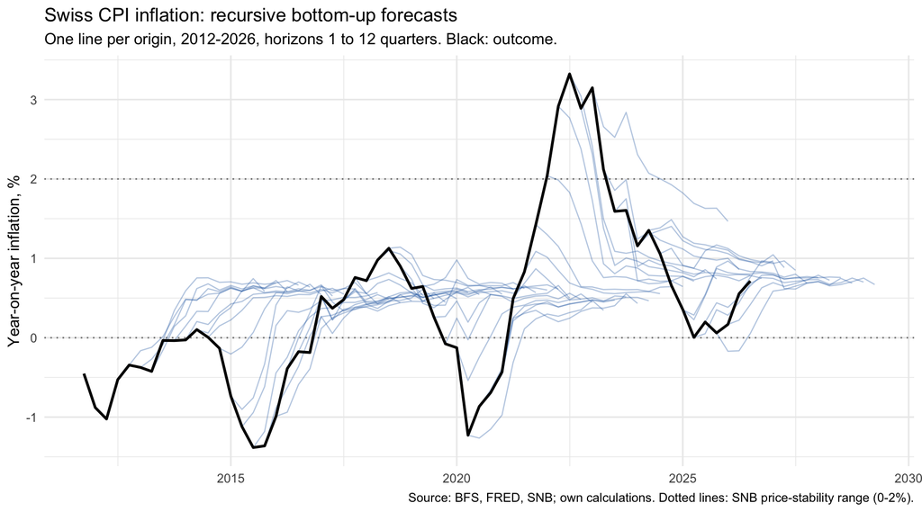

```r
# Each thin line is the 12-quarter forecast made at one origin, starting from
# the inflation rate observed at that origin. The thick line is the outcome.
paths <- bind_rows(
  recursive %>% select(origin, target, value = model),
  recursive %>% distinct(origin, value = pi_origin) %>% mutate(target = origin))

spaghetti <- ggplot() +
  geom_hline(yintercept = c(0, 2), linetype = "dotted", colour = "grey50") +
  geom_line(data = paths, aes(target, value, group = origin),
            colour = "#2b6cb0", alpha = 0.35, linewidth = 0.4) +
  geom_line(data = filter(q, date >= first_origin - years(1)),
            aes(date, pi_cpi), colour = "black", linewidth = 0.9) +
  labs(title = "Swiss CPI inflation: recursive bottom-up forecasts",
       subtitle = paste0("One line per origin, ", format(min(recursive$origin), "%Y"),
                         "-", format(max(recursive$origin), "%Y"),
                         ", horizons 1 to ", H, " quarters. Black: outcome."),
       x = NULL, y = "Year-on-year inflation, %",
       caption = "Source: BFS, FRED, SNB; own calculations. Dotted lines: SNB price-stability range (0-2%).") +
  theme_minimal(base_size = 11)

spaghetti
```

```r
ggsave(here("figures", "jumeau", "spaghetti_headline.png"), spaghetti,
       width = 9, height = 5, dpi = 300, bg = "white")
```

The forecasts follow the outcome closely over the first quarters and then converge to the long-run inflation implied by the block drifts. They therefore do not anticipate the large shocks of the evaluation period: the removal of the EUR/CHF floor in 2015, the COVID-19 shock in 2020 and the 2021–2023 surge. Such events are not predictable from past inflation, and time-series models without information on them are not expected to foresee them. After each shock, the new forecasts quickly adjust to the observed level.